# Rare Disease Celltyping

HPO annotations

Brian M. Schilder

**Source**

```r
library(data.table)
```

All HPO annotations comes from directly from the HPO site: https://hpo.jax.org/app/data/annotations

Detailed columns descriptions: https://hpo-annotation-qc.readthedocs.io/en/latest/annotationFormat.html#phenotype-hpoa-format

# Count metadata annotations

## Parse metadata

**Source**

```r
d <- HPOExplorer::load_phenotype_to_genes(3)
```

**Message**

```
## Importing existing file: ... phenotype.hpoa
```

**Source**

```r
{
  d[,DiseaseDB:=sapply(DatabaseID,function(x){strsplit(x,":")[[1]][1]})]
  d <- HPOExplorer::add_death(d, agg_by = "DatabaseID")
  d <- HPOExplorer::add_ndisease(d)
  d <- HPOExplorer::add_ancestor(d)
  d <- HPOExplorer::add_pheno_frequency(d)
  d <- HPOExplorer::add_ont_lvl(d)
  d <- HPOExplorer::add_onset(d)
  d <- HPOExplorer::add_severity(d)
  d <- HPOExplorer::add_tier(d)
}
```

**Message**

```
## Annotating phenos with AgeOfDeath
```

**Message**

```
## Annotating phenos with n_diseases
```

**Message**

```
## Importing existing file: ... phenotype_to_genes.txt
```

**Message**

```
## Importing existing file: ... genes_to_phenotype.txt
```

**Message**

```
## Importing existing file: ... phenotype.hpoa
```

**Message**

```
## Adding level-3 ancestor to each HPO ID.
```

**Message**

```
## Annotating phenotype frequencies.
```

**Message**

```
## Getting absolute ontology level for 10,550 HPO IDs.
```

**Message**

```
## Annotating phenos with Onset.
```

**Message**

```
## Annotating phenos with Modifiers
```

**Message**

```
## Annotating phenos with Tiers.
```

### Unique values per attribute

**Source**

```r
all_vars <- c(
  "Qualifier","Evidence","Sex","Aspect","Biocuration",
  "DiseaseDB","ancestor_name",
  "AgeOfDeath_names","AgeOfDeath_earliest","AgeOfDeath_latest",
  "AgeOfDeath_score_min","AgeOfDeath_score_max","AgeOfDeath_score_mean",
  "pheno_freq_name","pheno_freq_min","pheno_freq_max",
  "Onset_name","Modifier_name","Severity_score",
  "tier","tier_auto","tier_merge")
#### Only select variables with <N unique values ####
n_uniq <- lapply(stats::setNames(all_vars,
                                 all_vars),
                 function(x){ length(unique(unlist(d[[x]]))) })
print(n_uniq)
```

**Output**

```
## $Qualifier
## [1] 2
##
## $Evidence
## [1] 3
##
## $Sex
## [1] 5
##
## $Aspect
## [1] 4
##
## $Biocuration
## [1] 8267
##
## $DiseaseDB
## [1] 3
##
## $ancestor_name
## [1] 34
##
## $AgeOfDeath_names
## [1] 10
##
## $AgeOfDeath_earliest
## [1] 8
##
## $AgeOfDeath_latest
## [1] 7
##
## $AgeOfDeath_score_min
## [1] 8
##
## $AgeOfDeath_score_max
## [1] 7
##
## $AgeOfDeath_score_mean
## [1] 13
##
## $pheno_freq_name
```

[output cut: 10 more lines]

```
##
## $Modifier_name
## [1] 40
##
## $Severity_score
## [1] 5
##
## $tier
## [1] 5
##
## $tier_auto
## [1] 5
##
## $tier_merge
## [1] 5
```

**Source**

```r
#### Filter variables ####
## Must contain less than 20 unique values
vars <- all_vars[n_uniq<20]

aod_vars <- grep("AgeOfDeath",vars, value = TRUE)
vars <- vars[!vars %in% aod_vars]
aod_vars <- aod_vars[!aod_vars %in% c("AgeOfDeath_names","AgeOfDeath_counts")]
```

### Plot proportions

**Source**

```r
plot_proportions <- function(d,
                             vars,
                             drop_na=FALSE){
  lapply(stats::setNames(vars,
                         vars),
               function(v){
  dat <- d[,..v]
  dat[get(names(dat)[1])=="",] <- NA
  if(isTRUE(drop_na)){
    dat <- dat[!is.na(get(names(dat)[1])),]
  }
  dat[[1]] <- factor(dat[[1]])
  ggplot2::ggplot(dat,
                  ggplot2::aes_string(x="1", fill=names(dat)[1])) +
    ggplot2::geom_bar(stat = "count",
                      position = ggplot2::position_stack()) +
    ggplot2::labs(x=NULL, title=v) +
    ggplot2::theme_minimal() +
    ggplot2::theme(axis.text.x = ggplot2::element_blank())
  })
}
```

#### Most attributes

**Source**

```r
plts <- plot_proportions(d = d,
                         vars = vars)
```

**Warning**

```
## Warning: `aes_string()` was deprecated in ggplot2 3.0.0.
## ℹ Please use tidy evaluation ideoms with `aes()`
## This warning is displayed once every 8 hours.
## Call `lifecycle::last_lifecycle_warnings()` to see where this warning was
## generated.
```

**Source**

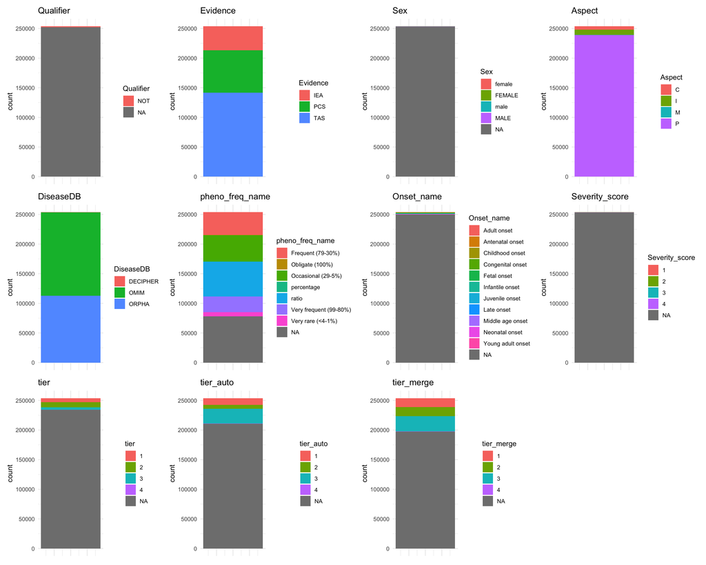

```r
pw <- patchwork::wrap_plots(plts)
print(pw)
```

#### AgeOfDeath attributes

Plot these separately simply to avoid overplotting.

**Source**

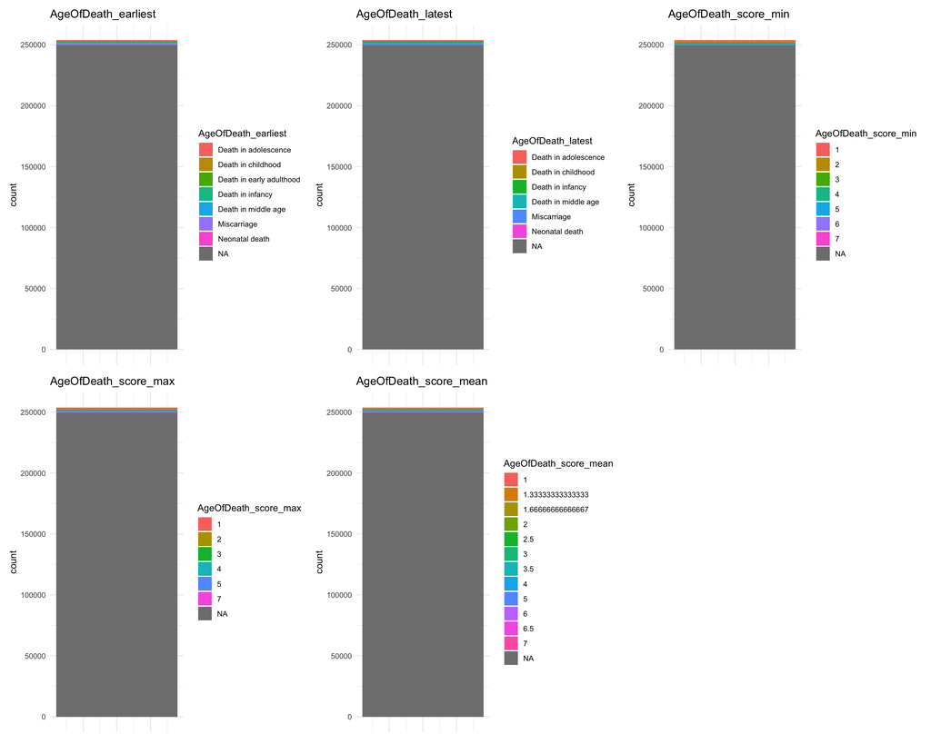

```r
aod_plts <- plot_proportions(d = d,
                             vars = aod_vars)
aod_pw <- patchwork::wrap_plots(aod_plts)
print(aod_pw)
```

Plot again, but without the NA values so we can better see the proportions for diseases that are annotated.

**Source**

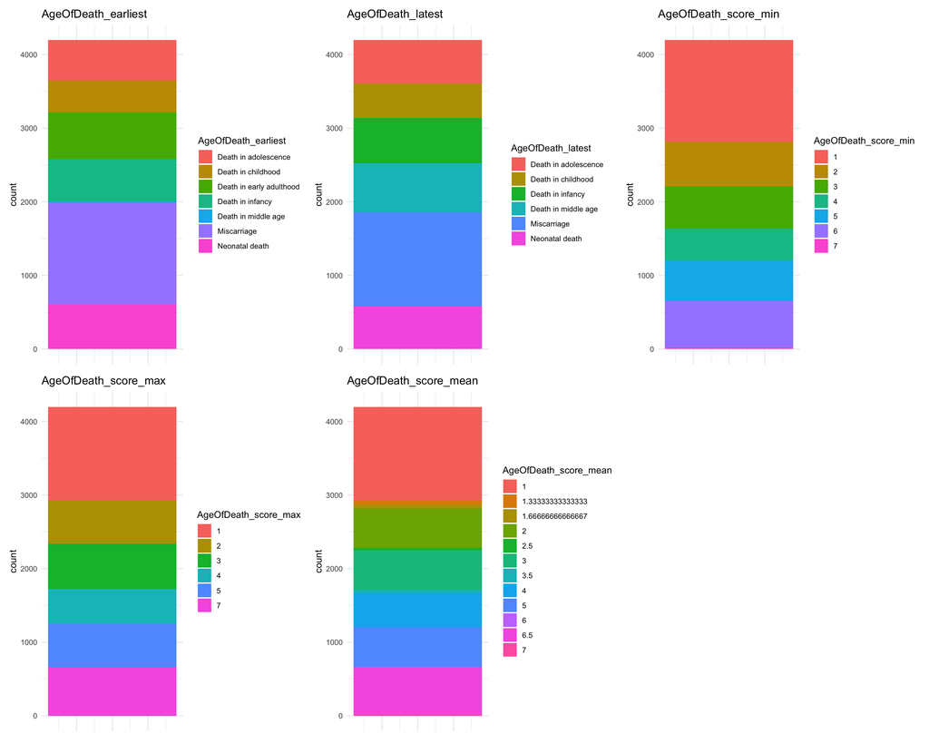

```r
aod_plts <- plot_proportions(d = d,
                             vars = aod_vars,
                             drop_na = TRUE)
aod_pw <- patchwork::wrap_plots(aod_plts)
print(aod_pw)
```

### Count frequencies

Show the top 20 most frequent values for each of the metadata attributes.

**Source**

```r
counts <- lapply(stats::setNames(all_vars,
                                 all_vars),
                 function(v){
  dat <- d[,..v]
  dat[get(names(dat)[1])=="",] <- NA
  head(sort(table(unlist(dat[[1]]), useNA = "always"),
       decreasing = TRUE),20)
})
print(counts)
```

**Output**

```
## $Qualifier
##
##   <NA>    NOT
## 252320   1452
##
## $Evidence
##
##    TAS    PCS    IEA   <NA>
## 141758  71619  40395      0
##
## $Sex
##
##   <NA>   MALE FEMALE   male female
## 253149    335    165     90     33
##
## $Aspect
##
##      P      I      C      M   <NA>
## 239020   8833   5743    176      0
##
## $Biocuration
##
## ORPHA:orphadata[2022-12-20]         HPO:iea[2009-02-17]
##                      112897                       26965
##    HPO:skoehler[2017-07-13]    HPO:skoehler[2012-10-17]
##                        4264                        4038
##    HPO:skoehler[2018-10-08]   HPO:probinson[2009-02-17]
##                        3701                        3277
##    HPO:skoehler[2019-04-18]    HPO:skoehler[2010-06-20]
##                        1722                        1675
##    HPO:skoehler[2015-12-30]    HPO:skoehler[2019-09-07]
##                        1434                        1404
##    HPO:skoehler[2010-06-19]    HPO:skoehler[2009-02-17]
##                        1346                         932
##    HPO:skoehler[2010-06-18]    HPO:skoehler[2019-02-15]
##                         823                         796
##    HPO:skoehler[2012-11-18]         HPO:iea[2012-04-24]
##                         597                         535
##   HPO:probinson[2017-06-17]    HPO:skoehler[2014-11-26]
##                         533                         507
```

[output cut: 172 more lines]

```
##
## $tier
##
##   <NA>      2      1      3      4
## 234019   8706   6645   4294    108
##
## $tier_auto
##
##   <NA>      3      1      2      4
## 210507  24828  11161   6968    308
##
## $tier_merge
##
##   <NA>      3      2      1      4
## 197518  25591  15464  14891    308
```

# Count X per Y

**Count** :

- diseases per phenotype
- phenotypes per disease
- genes per phenotype
- genes per disease

## phenotype.hpoa file

**Source**

```r
annot <- HPOExplorer::load_phenotype_to_genes(3)
```

**Message**

```
## Importing existing file: ... phenotype.hpoa
```

### Number of phenotypes/disease

**Source**

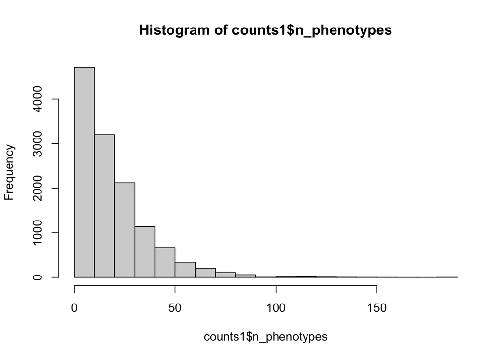

```r
counts1 <- annot[,list(n_phenotypes=length(unique(HPO_ID))),by="DatabaseID"]
hist(counts1$n_phenotypes)
```

**Source**

```r
summary(counts1$n_phenotypes)
```

**Output**

```
##    Min. 1st Qu.  Median    Mean 3rd Qu.    Max.
##    1.00    7.00   15.00   19.97   27.00  188.00
```

#### Number of diseases/phenotype

**Source**

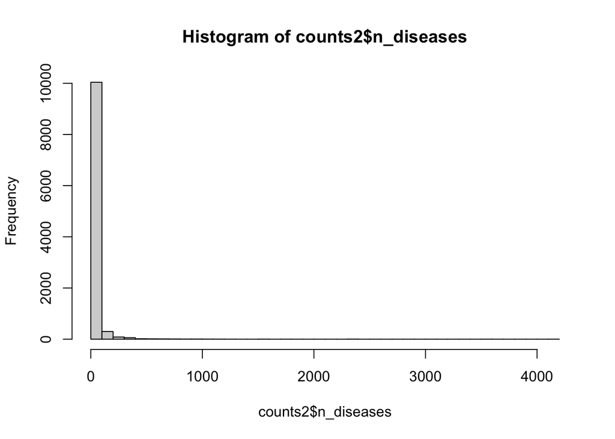

```r
counts2 <- annot[,list(n_diseases=length(unique(DatabaseID))),by="HPO_ID"]
hist(counts2$n_diseases, 50)
```

**Source**

```r
summary(counts2$n_diseases)
```

**Output**

```
##    Min. 1st Qu.  Median    Mean 3rd Qu.    Max.
##    1.00    2.00    4.00   23.91   14.00 4125.00
```

> http://purl.obolibrary.org/obo/hp/hpoa/genes_to_phenotype.txt provides a link between genes and HPO terms. All phenotype terms associated with any disease that is associated with variants in a gene are assigned to that gene in this file. Other files are available on our Jenkins server that filter terms according to provenance of the annotation and frequency of the features in the disease.

**Source**

```r
annot <- HPOExplorer::load_phenotype_to_genes(1)
```

**Message**

```
## Importing existing file: ... phenotype_to_genes.txt
```

**Source**

```r
data.table::setnames(annot,"LinkID","DatabaseID")
```

### Number of phenotypes/disease

**Source**

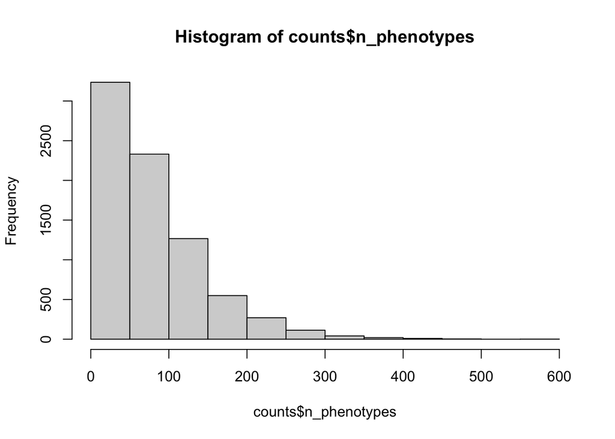

```r
counts <- annot[,list(n_phenotypes=length(unique(HPO_ID)),
                      n_genes=length(unique(Gene))),
                 by="DatabaseID"]
hist(counts$n_phenotypes)
```

**Source**

```r
summary(counts$n_phenotypes)
```

**Output**

```
##    Min. 1st Qu.  Median    Mean 3rd Qu.    Max.
##    1.00   30.50   63.00   79.33  110.00  568.00
```

**Source**

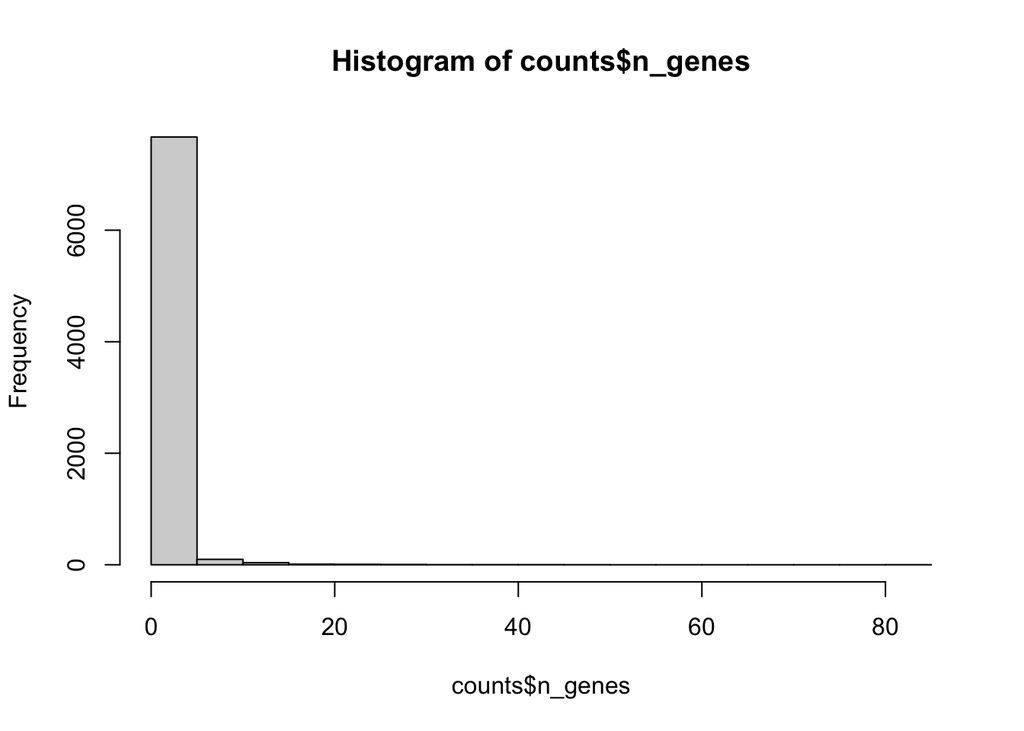

```r
hist(counts$n_genes)
```

**Source**

```r
summary(counts$n_genes)
```

**Output**

```
##    Min. 1st Qu.  Median    Mean 3rd Qu.    Max.
##   1.000   1.000   1.000   1.415   1.000  82.000
```

#### Number of diseases/phenotype

**Source**

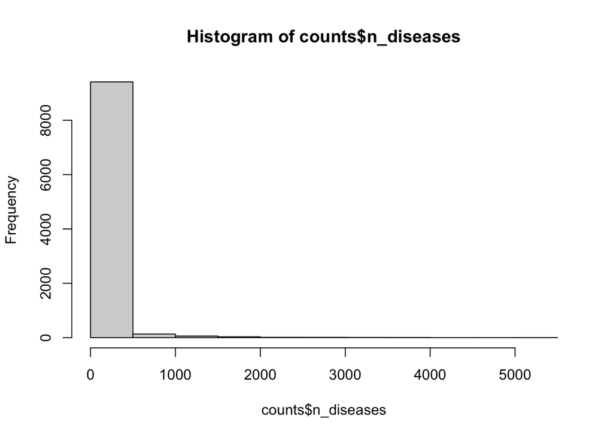

```r
counts <- annot[,list(n_diseases=length(unique(DatabaseID)),
                       n_genes=length(unique(Gene))),
                 by="HPO_ID"]
hist(counts$n_diseases)
```

**Source**

```r
summary(counts$n_diseases)
```

**Output**

```
##    Min. 1st Qu.  Median    Mean 3rd Qu.    Max.
##    1.00    2.00    6.00   64.27   25.00 5182.00
```

**Source**

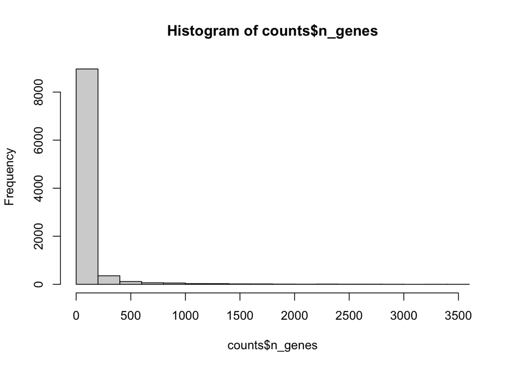

```r
hist(counts$n_genes)
```

**Source**

```r
summary(counts$n_genes)
```

**Output**

```
##    Min. 1st Qu.  Median    Mean 3rd Qu.    Max.
##    1.00    2.00    7.00   67.74   34.00 3484.00
```

> http://purl.obolibrary.org/obo/hp/hpoa/phenotype_to_genes.txt is analogous, but instead provides links from HPO terms to genes.

**Source**

```r
annot <- HPOExplorer::load_phenotype_to_genes(2)
```

**Message**

```
## Importing existing file: ... genes_to_phenotype.txt
```

**Source**

```r
data.table::setnames(annot,"LinkID","DatabaseID")
```

### Number of phenotypes/disease

**Source**

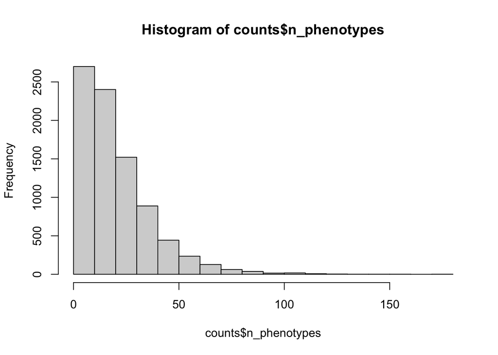

```r
counts <- annot[,list(n_phenotypes=length(unique(HPO_ID)),
                      n_genes=length(unique(Gene))),
                 by="DatabaseID"]
hist(counts$n_phenotypes)
```

**Source**

```r
summary(counts$n_phenotypes)
```

**Output**

```
##    Min. 1st Qu.  Median    Mean 3rd Qu.    Max.
##    1.00    8.00   17.00   20.78   28.00  172.00
```

**Source**

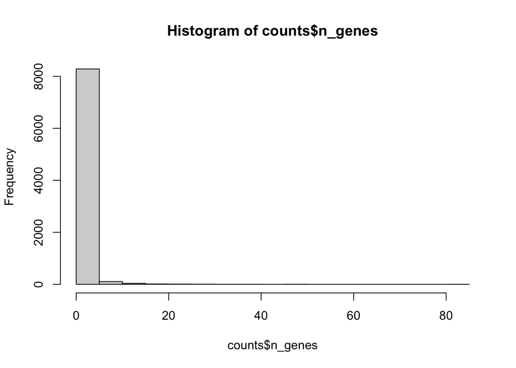

```r
hist(counts$n_genes)
```

**Source**

```r
summary(counts$n_genes)
```

**Output**

```
##    Min. 1st Qu.  Median    Mean 3rd Qu.    Max.
##   1.000   1.000   1.000   1.399   1.000  84.000
```

#### Number of diseases/phenotype

**Source**

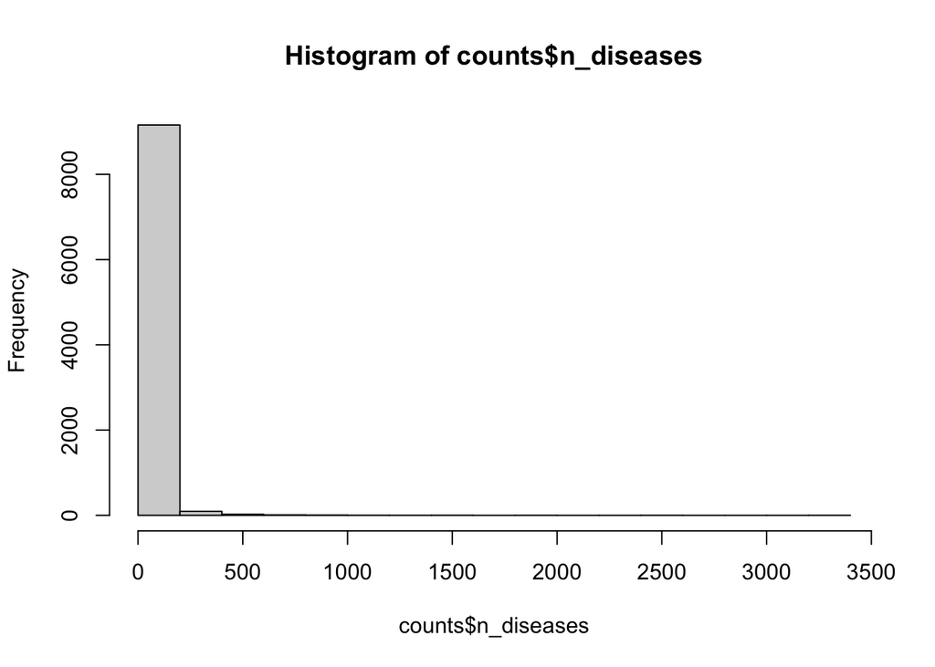

```r
counts <- annot[,list(n_diseases=length(unique(DatabaseID)),
                      n_genes=length(unique(Gene))),
                 by="HPO_ID"]
hist(counts$n_diseases)
```

**Source**

```r
summary(counts$n_diseases)
```

**Output**

```
##    Min. 1st Qu.  Median    Mean 3rd Qu.    Max.
##    1.00    1.00    4.00   18.91   11.00 3305.00
```

**Source**

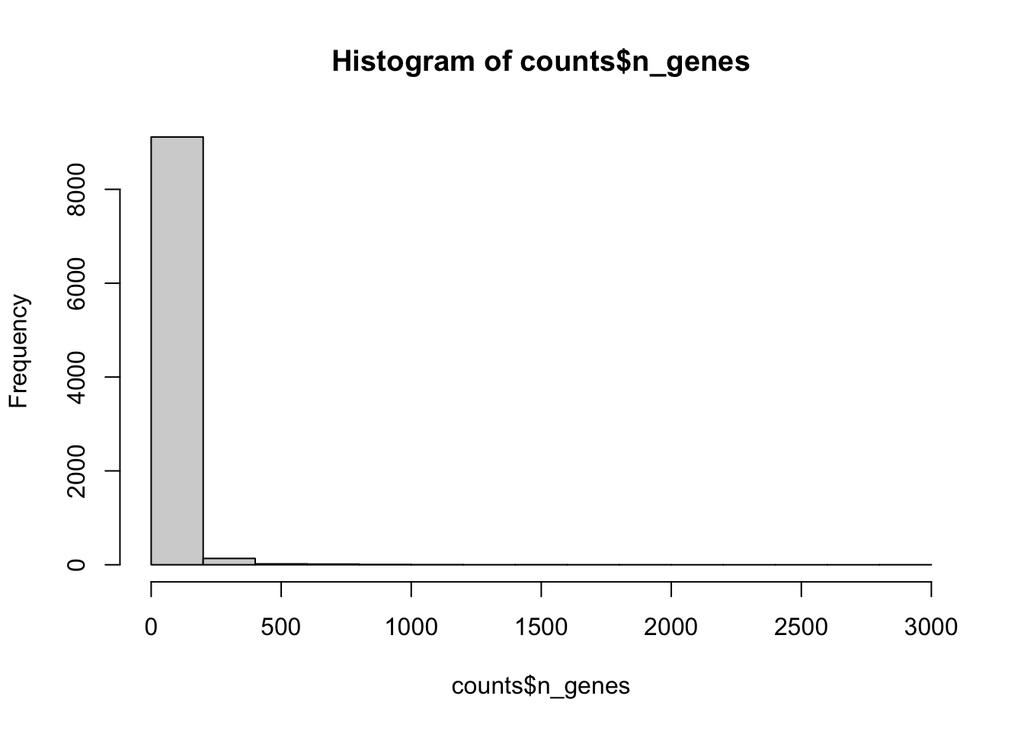

```r
hist(counts$n_genes)
```

**Source**

```r
summary(counts$n_genes)
```

**Output**

```
##    Min. 1st Qu.  Median    Mean 3rd Qu.    Max.
##    1.00    2.00    5.00   23.59   17.00 2924.00
```

# Session info

**Source**